# Final Project Proposal

MGSC 310 Final Projet Proposal

Hudson Pak, Justin Lewinski, Everett Prussak

```r
library(Metrics)
```

[output not shown]

Summary Statistics

[output not shown]

```r
data <- read.csv('diabetes.csv')
data <- data[-7]
data <- data %>%
  mutate(bp_st = BloodPressure*SkinThickness,
         age_squared = Age * Age
         )

head(data)

summary(data)
```

```
  Pregnancies        Glucose      BloodPressure    SkinThickness
 Min.   : 0.000   Min.   :  0.0   Min.   :  0.00   Min.   : 0.00
 1st Qu.: 1.000   1st Qu.: 99.0   1st Qu.: 62.00   1st Qu.: 0.00
 Median : 3.000   Median :117.0   Median : 72.00   Median :23.00
 Mean   : 3.845   Mean   :120.9   Mean   : 69.11   Mean   :20.54
 3rd Qu.: 6.000   3rd Qu.:140.2   3rd Qu.: 80.00   3rd Qu.:32.00
 Max.   :17.000   Max.   :199.0   Max.   :122.00   Max.   :99.00
    Insulin           BMI             Age           Outcome
 Min.   :  0.0   Min.   : 0.00   Min.   :21.00   Min.   :0.000
 1st Qu.:  0.0   1st Qu.:27.30   1st Qu.:24.00   1st Qu.:0.000
 Median : 30.5   Median :32.00   Median :29.00   Median :0.000
 Mean   : 79.8   Mean   :31.99   Mean   :33.24   Mean   :0.349
 3rd Qu.:127.2   3rd Qu.:36.60   3rd Qu.:41.00   3rd Qu.:1.000
 Max.   :846.0   Max.   :67.10   Max.   :81.00   Max.   :1.000
     bp_st       age_squared
 Min.   :   0   Min.   : 441
 1st Qu.:   0   1st Qu.: 576
 Median :1504   Median : 841
 Mean   :1483   Mean   :1243
 3rd Qu.:2326   3rd Qu.:1681
 Max.   :6930   Max.   :6561
```

age_squared and bp_st are created because the original model was slightly underfit. By adding these created variables, the model became mode complex and allowed for the model to be less underfit.

Train-Test-Split

```r
# code
library(rsample)
set.seed(310)
data_split <- initial_split(data,prop=0.8)
data_train <- training(data_split)
data_test <- testing(data_split)
```

Logistic Regression Model

```r
logit <- glm(Outcome ~ .,
             data = data_train,
             family = binomial
             )

summary(logit)
```

```
Call:
glm(formula = Outcome ~ ., family = binomial, data = data_train)

Deviance Residuals:
    Min       1Q   Median       3Q      Max
-2.3309  -0.7044  -0.3710   0.6976   2.5671

Coefficients:
                 Estimate  Std. Error z value             Pr(>|z|)
(Intercept)   -12.4770044   1.4320939  -8.712 < 0.0000000000000002
Pregnancies     0.0719663   0.0398282   1.807               0.0708
Glucose         0.0333951   0.0042207   7.912  0.00000000000000253
BloodPressure  -0.0171458   0.0071033  -2.414               0.0158
SkinThickness  -0.0091217   0.0284764  -0.320               0.7487
Insulin        -0.0008445   0.0009771  -0.864               0.3874
BMI             0.0833801   0.0172582   4.831  0.00000135627984346
Age             0.3090935   0.0649199   4.761  0.00000192490004070
bp_st           0.0001117   0.0003709   0.301               0.7633
age_squared    -0.0035147   0.0007676  -4.579  0.00000467683699402

(Intercept)   ***
Pregnancies   .
Glucose       ***
BloodPressure *
SkinThickness
Insulin
BMI           ***
Age           ***
bp_st
age_squared   ***
---
Signif. codes:  0 ‘***’ 0.001 ‘**’ 0.01 ‘*’ 0.05 ‘.’ 0.1 ‘ ’ 1

(Dispersion parameter for binomial family taken to be 1)

    Null deviance: 791.41  on 613  degrees of freedom
Residual deviance: 567.61  on 604  degrees of freedom
AIC: 587.61

Number of Fisher Scoring iterations: 5
```

At a 95% confidence Glucose, BloodPressure, BMI, Age, and age_squared are statistically significant.

Exponentiating Coefficients

```r
exp(logit$coefficients)
```

```
   (Intercept)    Pregnancies        Glucose  BloodPressure
0.000003813343 1.074619075630 1.033959003665 0.983000401004
 SkinThickness        Insulin            BMI            Age
0.990919822281 0.999155810098 1.086954902115 1.362189759326
         bp_st    age_squared
1.000111703491 0.996491463035
```

Interpretation for the variable ‘Glucose’ (Marginal Effect): he marginal effect of Glucose shows us that 1 unit increase in Glucose would result in 3.39 percent increase in likelihood of having diabetes.

Scoring the model:

```r
results_train <- data.frame(
  true_numeric = data_train$Outcome,
  true_factor = factor(data_train$Outcome),
  scores = predict(logit, type = 'response', newdata = data_train)
)

results_test <- data.frame(
  true_numeric = data_test$Outcome,
  true_factor = factor(data_test$Outcome),
  scores = predict(logit, type = 'response', newdata = data_test)
)
```

ROC Curves:

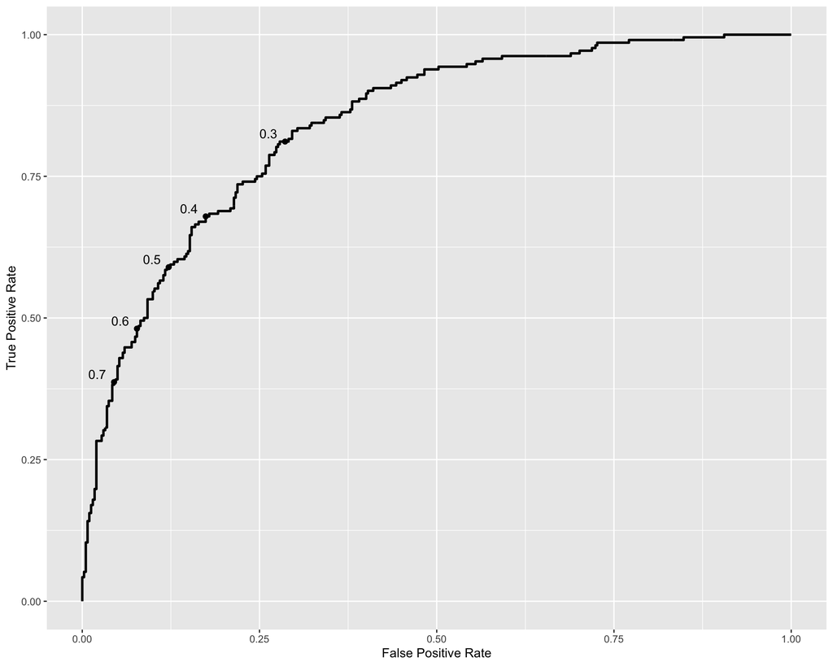

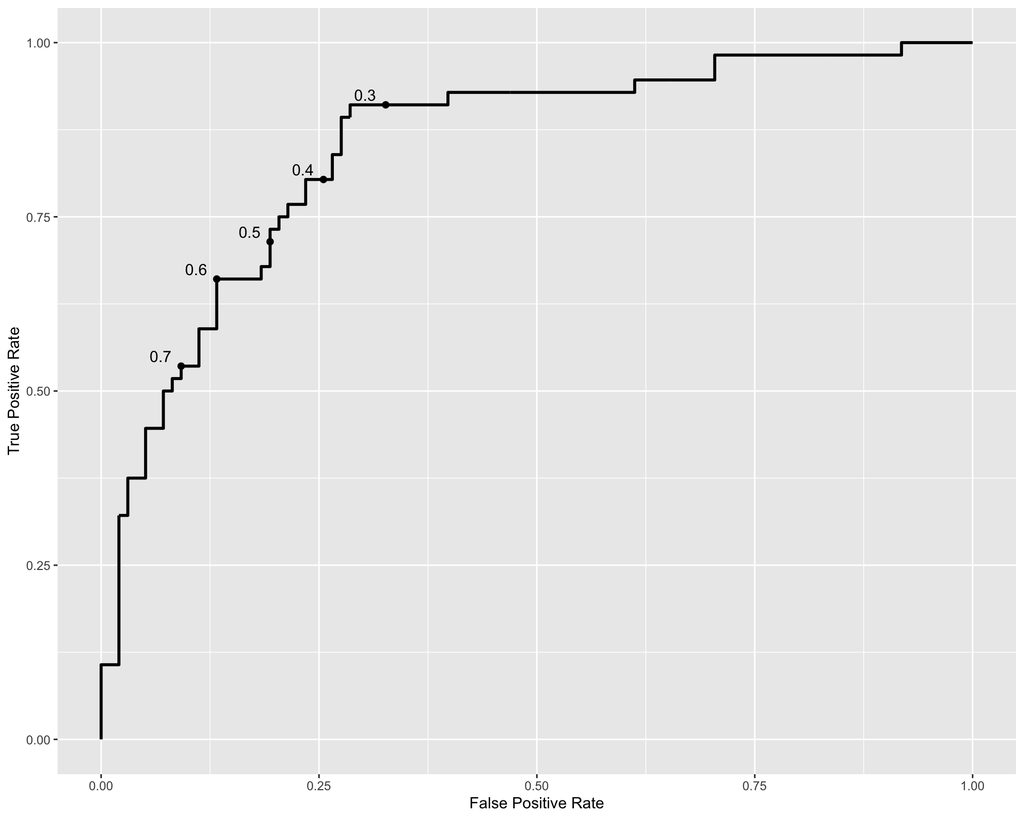

From these two graph’s, we chose a cutoff value of 0.3 because it seems to be a good cutoff as it results in balanced false and true positive rates.

Class Assignments

```r
predicted_train <- ifelse(results_train$scores>0.3,1,0)
results_train <- results_train %>%
  mutate(predicted = factor(predicted_train))

results_train %>% glimpse()
```

```
Rows: 614
Columns: 4
$ true_numeric <int> 1, 1, 0, 0, 1, 1, 0, 1, 1, 1, 1, 0, 0, 0, 0, …
$ true_factor  <fct> 1, 1, 0, 0, 1, 1, 0, 1, 1, 1, 1, 0, 0, 0, 0, …
$ scores       <dbl> 0.82928792, 0.08177297, 0.10062309, 0.0539890…
$ predicted    <fct> 1, 0, 0, 0, 0, 1, 0, 1, 1, 1, 1, 0, 0, 0, 0, …
```

```r
predicted_test <- ifelse(results_test$scores>0.3,1,0)
results_test <- results_test %>%
  mutate(predicted = factor(predicted_test))

results_test %>% glimpse()
```

```
Rows: 154
Columns: 4
$ true_numeric <int> 1, 1, 0, 1, 1, 1, 0, 0, 0, 0, 0, 0, 0, 0, 0, …
$ true_factor  <fct> 1, 1, 0, 1, 1, 1, 0, 0, 0, 0, 0, 0, 0, 0, 0, …
$ scores       <dbl> 0.79370358, 0.74531636, 0.73774096, 0.9001486…
$ predicted    <fct> 1, 1, 1, 1, 1, 1, 1, 0, 0, 0, 1, 0, 0, 0, 0, …
```

Train Confusion Matrix

```r
cm_train <- conf_mat(results_train, truth = true_factor, estimate = predicted)
print(cm_train)
```

```
          Truth
Prediction   0   1
         0 288  40
         1 114 172
```

Train Accuracy, Sensitivity, and Specificity Scores:

```r
accuracy <- (288+172) / (172+288+40+114)
paste0('Accuracy for the train is ', round(accuracy,4)*100, ' percent')
```

```
[1] "Accuracy for the train is 74.92 percent"
```

```r
sensitivity <- (172) / (172 + 40)
paste0('Sensitivity for the train is ', round(sensitivity,4)*100, ' percent')
```

```
[1] "Sensitivity for the train is 81.13 percent"
```

```r
specificity <- (288) / (288 + 114)
paste0('Specificity for the train is ', round(specificity,4)*100, ' percent')
```

```
[1] "Specificity for the train is 71.64 percent"
```

Test Confusion Matrix

```r
cm_test <- conf_mat(results_test, truth = true_factor, estimate = predicted)
print(cm_test)
```

```
          Truth
Prediction  0  1
         0 67  5
         1 31 51
```

Test Accuracy, Sensitivity, and Specificity Scores:

```r
accuracy <- (67+51) / (67+51+31+5)
paste0('Accuracy for the test is ', round(accuracy,4)*100, ' percent')
```

```
[1] "Accuracy for the test is 76.62 percent"
```

```r
sensitivity <- (51) / (51+5)
paste0('Sensitivity for the test is ', round(sensitivity,4)*100, ' percent')
```

```
[1] "Sensitivity for the test is 91.07 percent"
```

```r
specificity <- (67) / (67 + 31)
paste0('Specificity for the test is ', round(specificity,4)*100, ' percent')
```

```
[1] "Specificity for the test is 68.37 percent"
```

AUC

[output not shown]

```r
calc_auc(roc_train)

calc_auc(roc_test)
```

[output not shown]

|  | PANEL | group | AUC |
| --- | --- | --- | --- |
| 1 | 1 | -1 | 0.8494898 |

Lasso Model

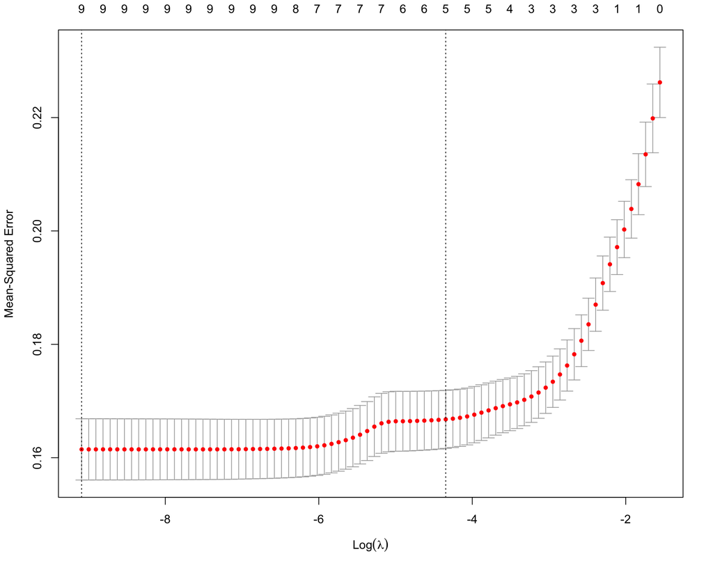

```r
lasso_mod <- cv.glmnet(Outcome ~ .,
                       data = data_train,
                       # note alpha = 1 sets Lasso!
                       alpha = 1)

plot(lasso_mod)
print(lasso_mod$lambda.min)
```

```
[1] 0.0001127317
```

```r
print(lasso_mod$lambda.1se)
```

```
[1] 0.01296141
```

```r
coef(lasso_mod, s = lasso_mod$lambda.min) %>%
  round(3)
```

```
10 x 1 sparse Matrix of class "dgCMatrix"
                  s1
(Intercept)   -1.401
Pregnancies    0.013
Glucose        0.006
BloodPressure -0.003
SkinThickness -0.003
Insulin        0.000
BMI            0.012
Age            0.045
bp_st          0.000
age_squared   -0.001
```

```r
coef(lasso_mod, s = lasso_mod$lambda.1se) %>%
  round(3)
```

```
10 x 1 sparse Matrix of class "dgCMatrix"
                  s1
(Intercept)   -0.716
Pregnancies    0.022
Glucose        0.005
BloodPressure -0.001
SkinThickness  .
Insulin        .
BMI            0.012
Age            0.001
bp_st          .
age_squared    .
```

```r
lasso_coefs <- data.frame(
  lasso_min = coef(lasso_mod, s = lasso_mod$lambda.min) %>%
    round(3) %>% as.matrix() ,
  lasso_1se = coef(lasso_mod, s = lasso_mod$lambda.1se) %>%
    round(3) %>% as.matrix()
) %>% rename(lasso_min = 1, lasso_1se = 2)

print(lasso_coefs)
```

|  | lasso_min | lasso_1se |
| --- | --- | --- |
| (Intercept) | -1.401 | -0.716 |
| Pregnancies | 0.013 | 0.022 |
| Glucose | 0.006 | 0.005 |
| BloodPressure | -0.003 | -0.001 |
| SkinThickness | -0.003 | 0.000 |
| Insulin | 0.000 | 0.000 |
| BMI | 0.012 | 0.012 |
| Age | 0.045 | 0.001 |
| bp_st | 0.000 | 0.000 |
| age_squared | -0.001 | 0.000 |

```r
library('coefplot')
coefpath(lasso_mod)
```

[interactive chart not shown]

```r
# number of non-zero predictors
lasso_coefs %>% head()
```

|  | lasso_min | lasso_1se |
| --- | --- | --- |
| (Intercept) | -1.401 | -0.716 |
| Pregnancies | 0.013 | 0.022 |
| Glucose | 0.006 | 0.005 |
| BloodPressure | -0.003 | -0.001 |
| SkinThickness | -0.003 | 0.000 |
| Insulin | 0.000 | 0.000 |

```r
# for lambda.min
lasso_coefs %>% filter(lasso_min != 0) %>%
  nrow()
```

```
[1] 8
```

```r
# for lambda.1se
lasso_coefs %>% filter(lasso_1se != 0) %>%
  nrow()
```

```
[1] 6
```

Performance of Lasso

```r
library(caret)
predict_train_1 <- predict(lasso_mod, s=lasso_mod$lambda.min,data_train)

predict_test_1 <- predict(lasso_mod,s = lasso_mod$lambda.min, data_test)

results_train_1 <- data_train %>% mutate(pred = predict_train_1)
RMSE(results_train_1$pred,results_train_1$Outcome)
```

```
[1] 0.3946979
```

```r
# test
results_test <- data_test %>% mutate(pred = predict_test_1)
RMSE(results_test_1$pred,results_test_1$Outcome)
```

[output not shown]